# notes:

- pandoc -s -S -i -t slidy –mathjax quickslide.md -o view.html –self-contained

  pandoc -t slidy -s slides -o view docs pycco -w *.py

# data

– Telehealth Readings/Day , %Change_Level

-

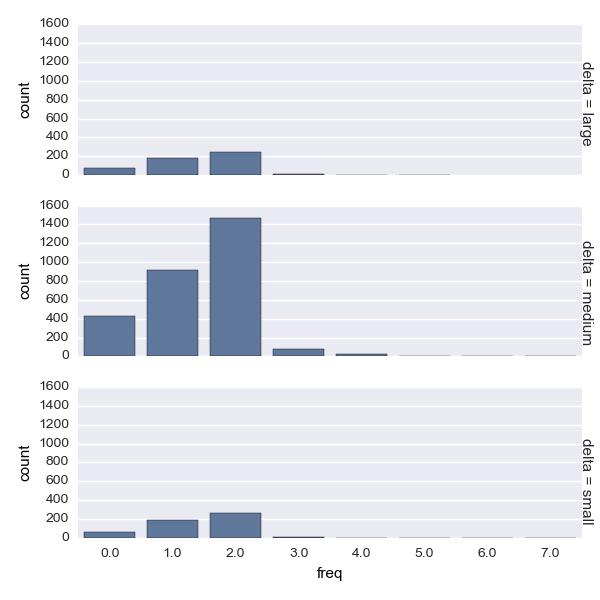

– ICU patients

-

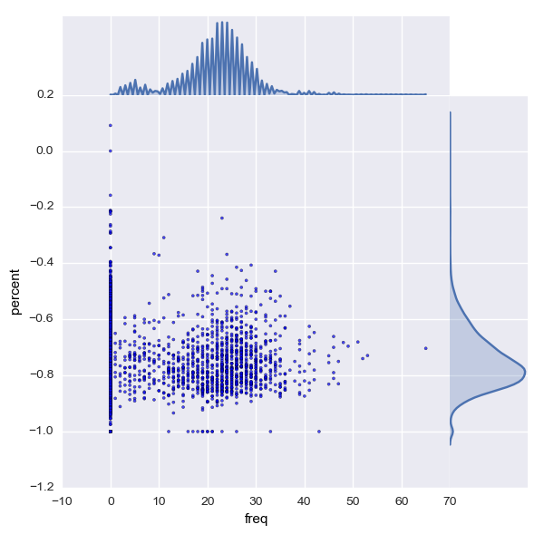

– mimic patient expire

-

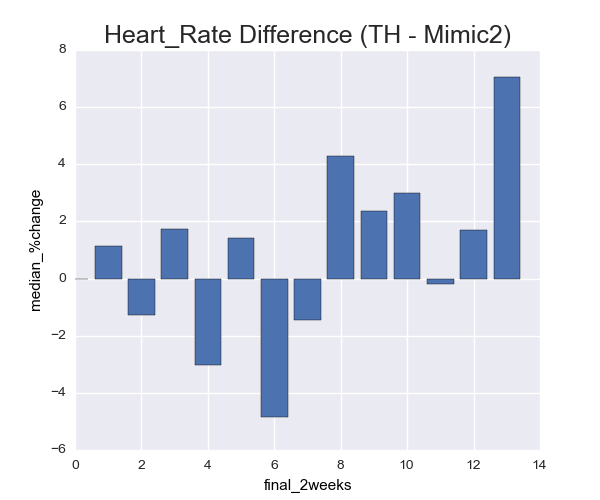

– demographic information

[figure not shown]

– log-normal distribution

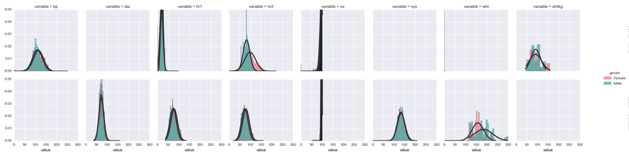

– categorical data

weekday trend

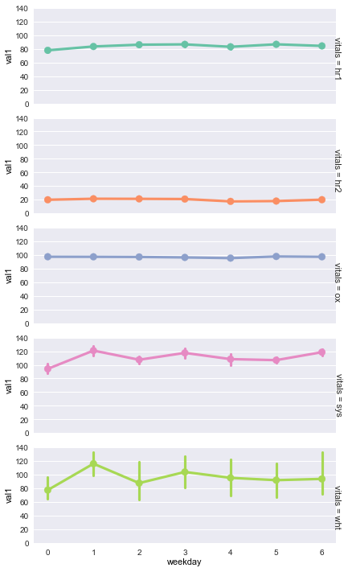

# boosting:

(needs to be rerun over full dataset) – weights:

-Weights/Iteration of Boosting

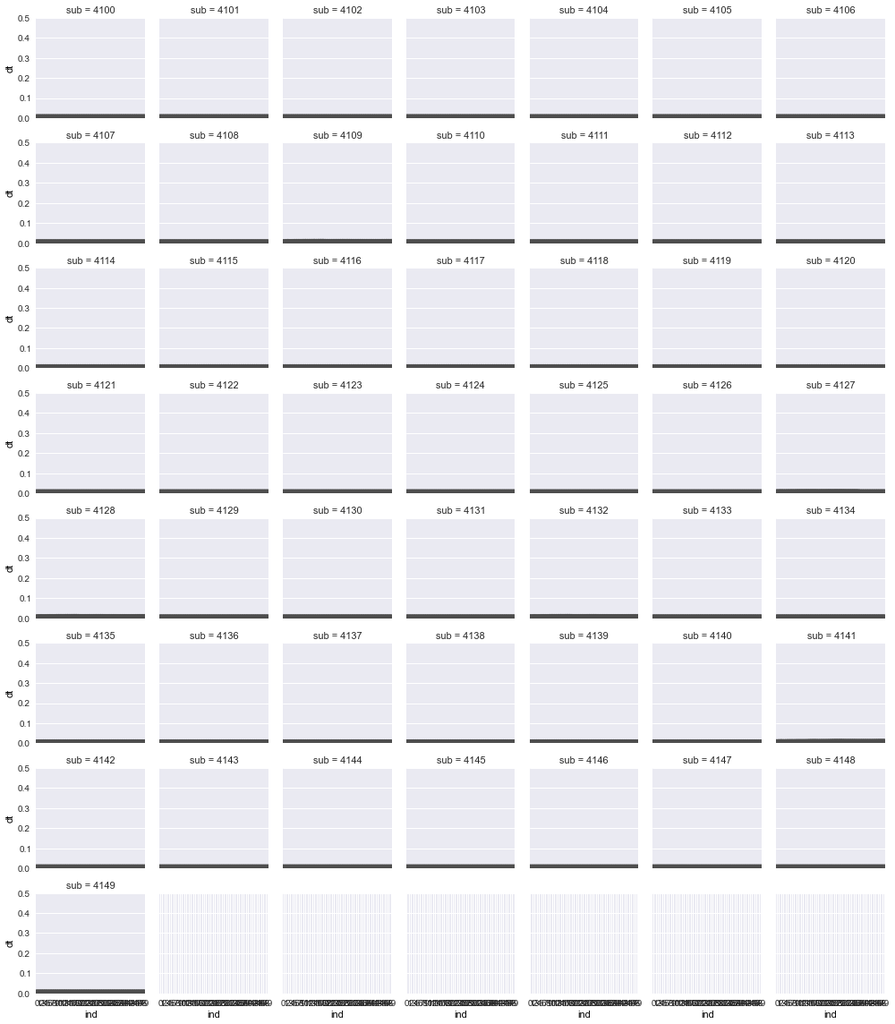

– Hard/Easy/Correct/Incorrect plot:

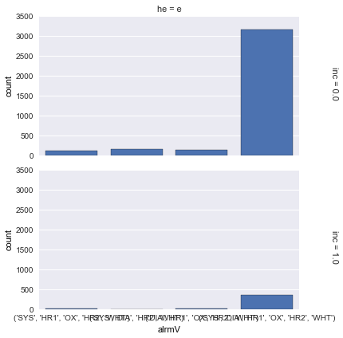

– logistic regression

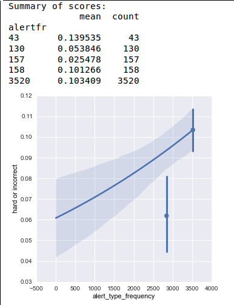

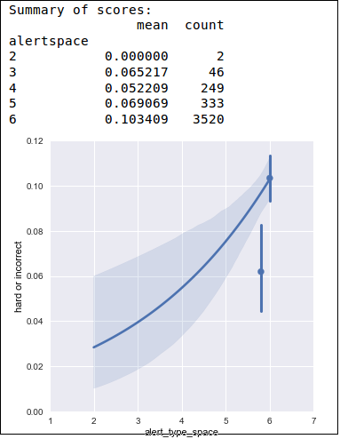

# alerts

## need to be rerun

– bootstrap ci (resample %_method, shown invariant to data normalization issues)

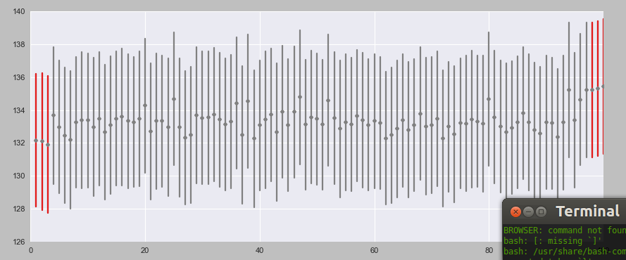

– kernel regression

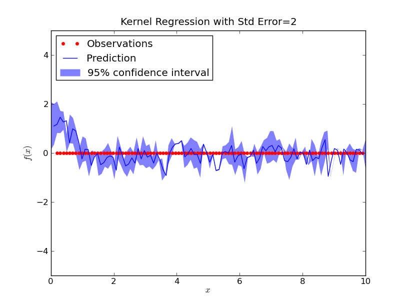

– FFT

– Bayes Change Point

# bayes

– prediction of care = P(#alert_distribution) + P(time_between_alerts)*weibull*prior + P(#alerts_unseen)

– effect size (number of patients needed)

– roulette method www.sr32  
– possible models:

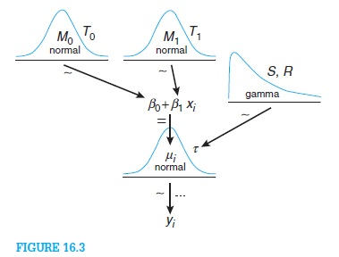

design likelihood function P(INTV) - probability(intervention)=distribution_over_alerts + distribution_time_between

causal modeling (Judea Perl)

# code + data

– github.com/ansatz/project/

– telehealth: I can deidentify and bootstrap the data, so the statistics are the same(mean, var) but the actual data is not shared.

– MIMIC2:

https://mimic2app.csail.mit.edu/ When register,Dr.Avitall will be contacted, to make sure its for clinical use and patient privacy issues; then authorize in 2-3days.